# 432 Lab 04

Steven Mayher

2022-03-22

## Setup

```r
library(knitr)
library(rmdformats)

## Global options
opts_chunk$set(comment=NA)
opts_knit$set(width=75)
```

## Package Loading

```r
library(conflicted)
library(here)
library(magrittr)
library(janitor)
library(broom)
library(rms)
library(Hmisc)
library(MASS)
library(pscl)
library(countreg)
library(tidyverse)

theme_set(theme_bw())
conflict_prefer("select", "dplyr")
conflict_prefer("filter", "dplyr")
options(dplyr.summarise.inform = FALSE)
```

## Import the `oh_counties_2020` Data

```r
oh20 <- read_csv(here("labs/lab04/data", "oh_counties_2020.csv"))

oh20 <- oh20 %>%
  clean_names() %>%
  type.convert(as.is = FALSE) %>%
  mutate(fips = as.character(fips))

oh20
```

| fips | state | county | years_lost_rate | sroh_fairpoor | phys_days | ment_days | lbw_pct | smoker_pct | obese_pct | food_env | inactive_pct | exer_access | exc_drink | alc_drive | sti_rate | teen_births | uninsured | pcp_ratio | prev_hosp | hsgrads | unemployed | poor_kids | income_ratio | associations | pm2_5 | h2oviol | sev_housing | drive_alone | age_adj_mortality | … |
| --- | --- | --- | --- | --- | --- | --- | --- | --- | --- | --- | --- | --- | --- | --- | --- | --- | --- | --- | --- | --- | --- | --- | --- | --- | --- | --- | --- | --- | --- | --- |
| 39001 | Ohio | Adams | 12223 | 22.30 | 4.94 | 4.83 | 9.05 | 24.28 | 32.2 | 7.1 | 36.6 | 41.7 | 16.06 | 37.50 | 216.4 | 40.03 | 9.06 | 2310 | 75.09 | 92.22 | 7.07 | 29.1 | 5.619 | 8.30 | 10.4 | No | 16 | 79 | 563.5 | … |
| 39003 | Ohio | Allen | 9037 | 16.50 | 4.12 | 4.40 | 9.35 | 20.18 | 34.0 | 7.5 | 27.5 | 75.8 | 16.74 | 31.48 | 587.2 | 30.49 | 7.70 | 1518 | 63.80 | 84.93 | 4.49 | 18.7 | 4.492 | 16.38 | 12.2 | No | 14 | 86 | 418.5 | … |
| 39005 | Ohio | Ashland | 7483 | 16.79 | 4.09 | 4.47 | 5.96 | 18.84 | 33.3 | 8.2 | 32.6 | 60.0 | 19.03 | 33.33 | 257.3 | 20.63 | 8.24 | 2063 | 49.98 | 94.06 | 4.58 | 12.6 | 3.688 | 19.02 | 11.3 | No | 14 | 84 | 372.1 | … |
| 39007 | Ohio | Ashtabula | 10013 | 16.77 | 4.18 | 4.57 | 8.16 | 21.28 | 37.6 | 6.9 | 33.7 | 73.1 | 16.98 | 39.02 | 305.7 | 32.54 | 8.30 | 2794 | 66.81 | 87.99 | 5.27 | 24.0 | 4.756 | 12.27 | 11.0 | Yes | 15 | 85 | 473.0 | … |
| 39009 | Ohio | Athens | 7014 | 20.62 | 4.66 | 4.92 | 8.55 | 20.03 | 33.4 | 5.8 | 26.7 | 83.0 | 20.13 | 21.62 | 800.3 | 8.80 | 9.32 | 1332 | 35.44 | 91.82 | 5.77 | 26.8 | 7.028 | 9.16 | 10.5 | Yes | 22 | 72 | 369.3 | … |
| 39011 | Ohio | Auglaize | 6454 | 14.57 | 3.73 | 4.27 | 7.32 | 17.45 | 38.3 | 8.6 | 31.1 | 77.7 | 18.50 | 16.67 | 233.7 | 23.53 | 5.66 | 2543 | 48.43 | 96.98 | 3.30 | 8.2 | 3.848 | 15.07 | 12.4 | No | 11 | 88 | 312.7 | … |
| 39013 | Ohio | Belmont | 8289 | 18.02 | 3.87 | 4.46 | 8.34 | 17.49 | 35.0 | 7.7 | 31.9 | 47.4 | 18.11 | 20.00 | 292.5 | 30.53 | 6.55 | 2721 | 84.58 | 89.49 | 5.47 | 17.7 | 4.653 | 15.73 | 11.2 | No | 9 | 89 | 414.3 | … |
| 39015 | Ohio | Brown | 10748 | 17.29 | 4.19 | 4.58 | 7.39 | 20.59 | 34.0 | 7.7 | 34.7 | 49.9 | 18.53 | 24.14 | 286.9 | 32.18 | 7.57 | 3631 | 59.42 | 93.60 | 5.36 | 18.4 | 4.255 | 5.74 | 11.0 | No | 12 | 82 | 527.2 | … |
| 39017 | Ohio | Butler | 9429 | 16.47 | 4.00 | 4.14 | 7.99 | 18.24 | 32.3 | 7.7 | 24.1 | 84.2 | 20.44 | 30.99 | 389.4 | 19.02 | 6.88 | 1848 | 57.64 | 90.45 | 4.13 | 15.4 | 4.566 | 8.41 | 13.0 | No | 14 | 85 | 421.8 | … |
| 39019 | Ohio | Carroll | 8073 | 16.21 | 4.08 | 4.39 | 7.61 | 18.37 | 38.6 | 8.1 | 31.6 | 30.9 | 16.72 | 15.00 | 248.3 | 24.19 | 7.78 | 5477 | 43.96 | 91.25 | 5.26 | 17.3 | 4.021 | 13.88 | 11.3 | No | 11 | 83 | 387.3 | … |

[output cut: 78 more lines]

# 1 Question 1

As stated in prompt A, Jeff Leek remarks in his book *How to Be A Modern Scientist* that “Everyone is an internet scientist now.” Upon reflection, I think that my work will change in regards to this remark, in particular regarding how much of my work may come from analyzing collected data from multiple studies as opposed to data collected on my own. While I do not think that this will mean in any way that I will necessarily stop producing data myself, the fact of the matter is that I may end up spending more time incorporating other collected data sets into studies than simply my own collected data in ways that have been previously untenable until the modern internet. Additionally, with Jeff Leek pointing out how “everyone is an internet scientist now”, it illustrates more than ever the importance of developing the proper skills to sift through the large amounts of data online in an efficient and effective manner. As time progresses the amount of data made available online will only continue to increase. As such the value of and necessity for skilled individuals capable of interpreting data will only increase moving forward, and as such I see myself continuing to develop the skills necessary to analyze large sets of data from multiple different sources online as necessary, as these skills will only become more relevant as time progresses. Admittedly , this makes being a scientist, to me anyways, both more and less appealing at the same time - the availability and accessibility of study data has never been higher, however as a result far more rigor will likely be required to discern effectively which data to use, which is credible and which isn’t, and many other related concerns for this matter.

# 2 Question 2

For this question, we will attempt to model the percentage of a county’s population that reports no leisure-time physical activity `inactive_pct` using the percentage of 16+ people who are unemployed but are looking for work (`unemployed`), the percentage of adults reporting a body mass index of 30 or higher (`obese_pct`), the percentage of people with access to places for physical activity (`exer_access`), percentage of people with frequent physical distress (`freq_phys_distress`), the percentage of people who get insufficient sleep (`insuff_sleep`), and the estimated median income of the county’s population (`median_income`). To accomplish this, the initial dataset `oh20` shown above will first be filtered to not include Cuyahoga or Monroe counties, and the resultant sub-set of data will be used to generate the necessary models using the **lm()** and **ols()** as shown below:

```r
lab04_data = oh20 %>%
  filter(county != "Cuyahoga") %>%
  filter(county != "Monroe")

d = datadist(lab04_data)
options(datadist = "d")

mod_q2_lm <- lm(inactive_pct ~ unemployed + obese_pct + exer_access + freq_phys_distress + insuff_sleep + median_income,
data = lab04_data, x = TRUE, y = TRUE)

mod_q2_ols <- ols(inactive_pct ~ unemployed + obese_pct + exer_access + freq_phys_distress + insuff_sleep + median_income,
data = lab04_data, x = TRUE, y = TRUE)
```

To assess how well a linear model fits the data, the R-squared, adjusted R-squared, AIC, and BIC values have been provided below:

```r
glance_mod_q2_lm = glance(mod_q2_lm) %>%
    select(r.squared, adj.r.squared, AIC, BIC) %>%
    kable(digits = c(3, 3, 1, 1))

glance_mod_q2_lm
```

| r.squared | adj.r.squared | AIC | BIC |
| --- | --- | --- | --- |
| 0.651 | 0.624 | 407.4 | 427.1 |

```r
set.seed(43202)
validate(mod_q2_ols)
```

```
          index.orig training   test optimism index.corrected  n
R-square      0.6509   0.6531 0.6168   0.0363          0.6147 40
MSE           5.5489   5.1468 6.0909  -0.9440          6.4929 40
g             3.5257   3.4455 3.4499  -0.0044          3.5301 40
Intercept     0.0000   0.0000 1.0502  -1.0502          1.0502 40
Slope         1.0000   1.0000 0.9656   0.0344          0.9656 40
```

```r
anova(mod_q2_lm)
```

|  | Df | Sum Sq | Mean Sq | F value | Pr(>F) |
| --- | --- | --- | --- | --- | --- |
| unemployed | 1 | 306.86472 | 306.864717 | 50.800784 | 4.258841e-10 |
| obese_pct | 1 | 303.62589 | 303.625885 | 50.264602 | 5.030652e-10 |
| exer_access | 1 | 76.36531 | 76.365312 | 12.642111 | 6.406695e-04 |
| freq_phys_distress | 1 | 141.09284 | 141.092838 | 23.357611 | 6.494447e-06 |
| insuff_sleep | 1 | 21.86581 | 21.865814 | 3.619838 | 6.073829e-02 |
| median_income | 1 | 40.09215 | 40.092152 | 6.637168 | 1.185039e-02 |
| Residuals | 79 | 477.20351 | 6.040551 | NA | NA |

To examine the linearity, normality, and other assumptions of the model, the following residual plots have been generated:

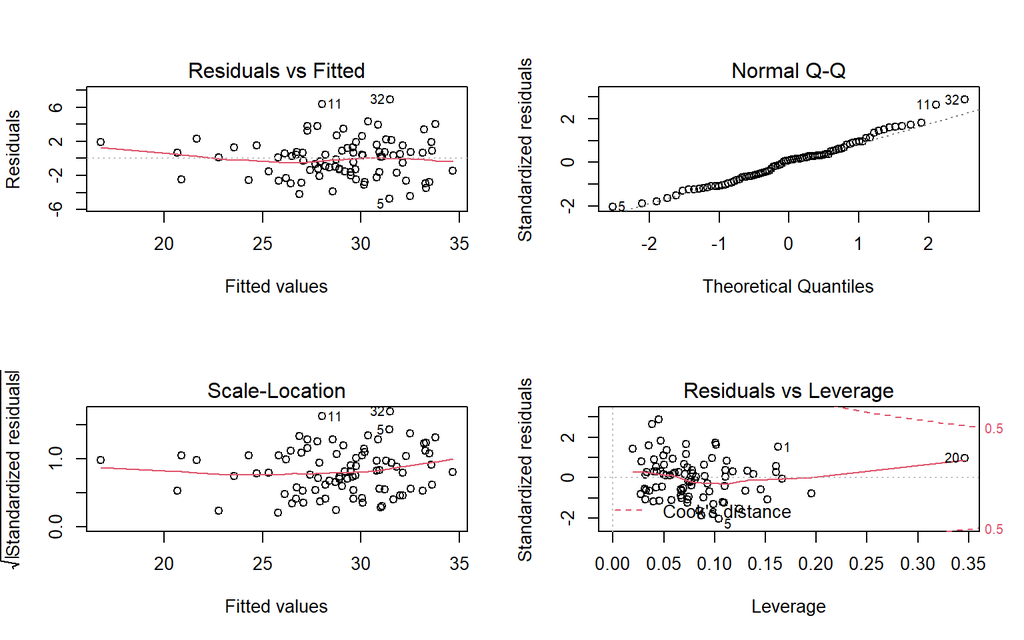

```r
par(mfrow = c(2,2)); plot(mod_q2_lm); par(mfrow = c(1,1))
```

The residual plots above suggest some issues with non-constant variance as well as some unusually high residuals, and at least one highly leveraged point, the latter of which has been identified below to be Delaware county:

```r
aug_mod_q2_lm = augment(mod_q2_lm, data = lab04_data)

aug_mod_q2_lm %>% select(county, .hat) %>%
  filter(.hat > 21/86) %>%
  arrange(desc(.hat))
```

| county | .hat |
| --- | --- |
| Delaware | 0.3464764 |

To see how well this model predicts the values for the Cuyahoga and Monroe counties the following code can be used:

```r
counties_test = oh20 %>% filter(county == "Cuyahoga" | county == "Monroe")

augment(mod_q2_lm, newdata = counties_test) %>% select(county, inactive_pct, .fitted, .resid) %>% kable()
```

| county | inactive_pct | .fitted | .resid |
| --- | --- | --- | --- |
| Cuyahoga | 24.8 | 27.12518 | -2.3251759 |
| Monroe | 31.1 | 30.22208 | 0.8779235 |

As can be seen above, the model predicts Monroe county’s `inactive_pct` better than it predicts the Cuyahoga county’s `inactive_pct`. For added benefit, a nomogram of the resultant model has been generated below:

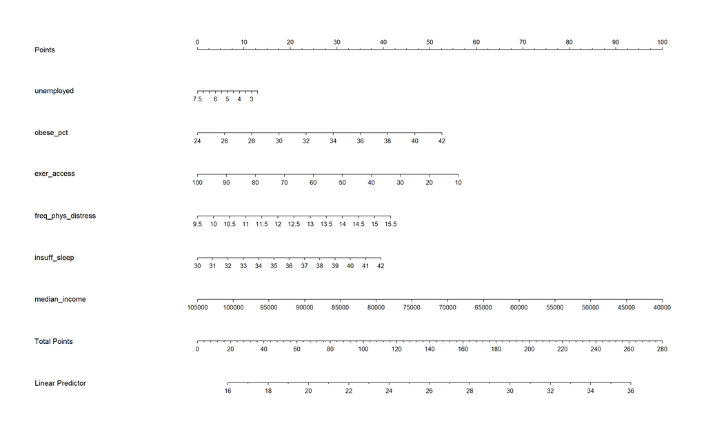

```r
plot(nomogram(mod_q2_ols))
```

# 3 Question 3

The following code generates the categorical version of the outcome variable as requested by the question prompt for use in generating the ordinal model:

```r
lab04_q3_data = lab04_data %>%
    mutate(years_lost_rate_cat = factor(Hmisc::cut2(years_lost_rate, g = 3)))

mosaic::favstats(years_lost_rate ~ years_lost_rate_cat, data = lab04_q3_data) %>%
    kable(digits = 3)
```

| years_lost_rate_cat | min | Q1 | median | Q3 | max | mean | sd | n | missing |
| --- | --- | --- | --- | --- | --- | --- | --- | --- | --- |
| [4125, 7845) | 4125 | 5977.0 | 7102 | 7524 | 7816 | 6763.931 | 957.749 | 29 | 0 |
| [7845, 9324) | 7845 | 8233.0 | 8549 | 8843 | 9158 | 8552.069 | 387.237 | 29 | 0 |
| [9324,13085] | 9324 | 9852.5 | 10113 | 11991 | 13085 | 10734.071 | 1196.691 | 28 | 0 |

```r
lab04_q3_data = lab04_q3_data %>%
    mutate(years_lost_rate_cat = fct_recode(years_lost_rate_cat,
                                   low = "[4125, 7845)",
                                   middle = "[7845, 9324)",
                                   high = "[9324,13085]"))

mosaic::favstats(years_lost_rate ~ years_lost_rate_cat, data = lab04_q3_data) %>%
    kable(digits = 3)
```

| years_lost_rate_cat | min | Q1 | median | Q3 | max | mean | sd | n | missing |
| --- | --- | --- | --- | --- | --- | --- | --- | --- | --- |
| low | 4125 | 5977.0 | 7102 | 7524 | 7816 | 6763.931 | 957.749 | 29 | 0 |
| middle | 7845 | 8233.0 | 8549 | 8843 | 9158 | 8552.069 | 387.237 | 29 | 0 |
| high | 9324 | 9852.5 | 10113 | 11991 | 13085 | 10734.071 | 1196.691 | 28 | 0 |

With the outcome variable prepared above, the code necessary for producing the model has been provided below:

```r
mod_q3_polr = polr(years_lost_rate_cat ~ sroh_fairpoor + inactive_pct + uninsured, data = lab04_q3_data, Hess = TRUE)

dd = datadist(lab04_q3_data)
options(datadist = "dd")

mod_q3_lrm = lrm(years_lost_rate_cat ~ sroh_fairpoor + inactive_pct + uninsured, data = lab04_q3_data,, x = TRUE, y = TRUE)
```

The following code provides a few of the summary statistics necessary for assessing this model:

```r
summary(mod_q3_polr)
```

```
Call:
polr(formula = years_lost_rate_cat ~ sroh_fairpoor + inactive_pct +
    uninsured, data = lab04_q3_data, Hess = TRUE)

Coefficients:
                Value Std. Error t value
sroh_fairpoor  0.9552    0.20187   4.732
inactive_pct   0.1398    0.07487   1.867
uninsured     -0.3264    0.29804  -1.095

Intercepts:
            Value   Std. Error t value
low|middle  16.7814  3.3111     5.0683
middle|high 19.2370  3.5113     5.4787

Residual Deviance: 127.5492
AIC: 137.5492
```

Nothing appears to be amiss with the coefficients for the model, and the model has an AIC of approximately 137.5492. The BIC value has been provided below:

```r
BIC(mod_q3_polr)
```

```
[1] 149.8209
```

And as can be seen below, the index-corrected (i.e. validated) R-squared value for this model is approximately 0.5571, which isn’t stellar, as that it just slightly better than randomly guessing the correct values:

```r
set.seed(43202)
validate(mod_q3_lrm)
```

```
          index.orig training    test optimism index.corrected  n
Dxy           0.7254   0.7183  0.7136   0.0047          0.7206 40
R2            0.5740   0.5762  0.5593   0.0169          0.5571 40
Intercept     0.0000   0.0000 -0.0204   0.0204         -0.0204 40
Slope         1.0000   1.0000  0.9407   0.0593          0.9407 40
Emax          0.0000   0.0000  0.0169   0.0169          0.0169 40
D             0.7022   0.7097  0.6762   0.0335          0.6687 40
U            -0.0233  -0.0233 -0.7873   0.7640         -0.7873 40
Q             0.7255   0.7329  1.4635  -0.7305          1.4560 40
B             0.1096   0.1040  0.1153  -0.0113          0.1209 40
g             2.8104   2.8594  2.7318   0.1276          2.6828 40
gp            0.3393   0.3371  0.3341   0.0030          0.3363 40
```

Lastly, the predictions for Cuyahoga county and Monroe county have been provided below with the following code:

```r
predict(mod_q3_lrm, newdata = counties_test, type = "fitted")
```

```
  y>=middle   y>=high
1 0.8985781 0.4318382
2 0.9276497 0.5237959
```

```r
predict(mod_q3_polr, newdata = counties_test, type = "p")
```

```
         low    middle      high
1 0.10159838 0.4669613 0.4314403
2 0.07232566 0.4037090 0.5239654
```

# 4 Question 4

To create the two regression models requested from this question, the outcome variable first needs to be generated as specified. The code below accomplishes this, labeling the outcome `sum`:

```r
lab04_q4_data = lab04_data %>%
  mutate(sroh_fairpoor_bin = if_else(sroh_fairpoor < 17.15, 1, 0)) %>%
  mutate(obese_pct_bin = if_else(obese_pct < 34.32, 1, 0)) %>%
  mutate(exer_access_bin = if_else(exer_access > 67.76, 1, 0)) %>%
  mutate(h2oviol_bin = if_else(h2oviol == "No", 1, 0))

lab04_q4_data = lab04_q4_data %>%
  mutate(sum = rowSums(lab04_q4_data[, c(44, 45, 46, 47)]))
```

With the outcome variable generated, the following two models have been generated, the first of which being just a standard linear regression model, and the second being a poisson regression model:

```r
mod_q4_lm = lm(sum ~ uninsured + food_insecure + inactive_pct, data = lab04_q4_data, x = TRUE, y = TRUE)
mod_q4_lm_ols = ols(sum ~ uninsured + food_insecure + inactive_pct, data = lab04_q4_data, x = TRUE, y = TRUE)

mod_q4_poiss = glm(sum ~ uninsured + food_insecure + inactive_pct, data = lab04_q4_data, x = TRUE, y = TRUE, family = poisson())
```

To compare how well both models fit the data, summaries of both have been provided below, with the first summary for the linear model:

```r
summary(mod_q4_lm)
```

```
Call:
lm(formula = sum ~ uninsured + food_insecure + inactive_pct,
    data = lab04_q4_data, x = TRUE, y = TRUE)

Residuals:
    Min      1Q  Median      3Q     Max
-2.3398 -0.7233  0.0375  0.7078  1.9483

Coefficients:
              Estimate Std. Error t value Pr(>|t|)
(Intercept)    7.00308    0.85502   8.191 2.93e-12 ***
uninsured     -0.01663    0.05167  -0.322    0.748
food_insecure -0.08127    0.05100  -1.594    0.115
inactive_pct  -0.12170    0.02947  -4.130 8.68e-05 ***
---
Signif. codes:  0 '***' 0.001 '**' 0.01 '*' 0.05 '.' 0.1 ' ' 1

Residual standard error: 0.9747 on 82 degrees of freedom
Multiple R-squared:  0.2843,    Adjusted R-squared:  0.2581
F-statistic: 10.86 on 3 and 82 DF,  p-value: 4.438e-06
```

And the second summary for the poisson model:

```r
summary(mod_q4_poiss)
```

```
Call:
glm(formula = sum ~ uninsured + food_insecure + inactive_pct,
    family = poisson(), data = lab04_q4_data, x = TRUE, y = TRUE)

Deviance Residuals:
     Min        1Q    Median        3Q       Max
-2.13012  -0.48639   0.03238   0.40429   1.25135

Coefficients:
               Estimate Std. Error z value Pr(>|z|)
(Intercept)    2.774017   0.535391   5.181  2.2e-07 ***
uninsured     -0.004102   0.034683  -0.118  0.90585
food_insecure -0.032536   0.034514  -0.943  0.34584
inactive_pct  -0.052562   0.020137  -2.610  0.00905 **
---
Signif. codes:  0 '***' 0.001 '**' 0.01 '*' 0.05 '.' 0.1 ' ' 1

(Dispersion parameter for poisson family taken to be 1)

    Null deviance: 58.273  on 85  degrees of freedom
Residual deviance: 45.016  on 82  degrees of freedom
AIC: 271.87

Number of Fisher Scoring iterations: 4
```

The AIC and BIC values for the linear model appear to be better than those for the poisson model:

```r
glance_mod_q4_lm = glance(mod_q4_lm) %>%
    select(r.squared, adj.r.squared, AIC, BIC) %>%
    kable(digits = c(3, 3, 1, 1))

glance_mod_q4_lm
```

| r.squared | adj.r.squared | AIC | BIC |
| --- | --- | --- | --- |
| 0.284 | 0.258 | 245.6 | 257.8 |

```r
glance_mod_q4_poiss = glance(mod_q4_poiss) %>%
    select(AIC, BIC) %>%
    kable(digits = c(1, 1))

glance_mod_q4_poiss
```

| AIC | BIC |
| --- | --- |
| 271.9 | 281.7 |

According to the following analyses of variance, the variance in both models is effectively identical:

```r
aov(mod_q4_lm)
```

```
Call:
   aov(formula = mod_q4_lm)

Terms:
                uninsured food_insecure inactive_pct Residuals
Sum of Squares    1.95366      12.78020     16.20690  77.90808
Deg. of Freedom         1             1            1        82

Residual standard error: 0.97473
Estimated effects may be unbalanced
```

```r
aov(mod_q4_poiss)
```

```
Call:
   aov(formula = mod_q4_poiss)

Terms:
                uninsured food_insecure inactive_pct Residuals
Sum of Squares    1.95366      12.78020     16.20690  77.90808
Deg. of Freedom         1             1            1        82

Residual standard error: 0.97473
Estimated effects may be unbalanced
```

```r
anova(mod_q4_lm, mod_q4_poiss)
```

|  | Res.Df | RSS | Df | Sum of Sq | F | Pr(>F) |
| --- | --- | --- | --- | --- | --- | --- |
| 1 | 82 | 77.90808 | NA | NA | NA | NA |
| 2 | 82 | 45.01553 | 0 | 32.89254 | NA | NA |

The validated R-square value for the linear model is as follows:

```r
set.seed(43202)
validate(mod_q4_lm_ols)
```

```
          index.orig training   test optimism index.corrected  n
R-square      0.2843   0.2691 0.2099   0.0591          0.2251 40
MSE           0.9059   0.9109 1.0000  -0.0891          0.9950 40
g             0.6779   0.6510 0.6251   0.0259          0.6520 40
Intercept     0.0000   0.0000 0.1642  -0.1642          0.1642 40
Slope         1.0000   1.0000 0.9417   0.0583          0.9417 40
```

Lastly, the following code provides the predictions for Cuyahoga county (1) and Monroe county (2) for both models:

```r
predict(mod_q4_lm, counties_test)
```

```
       1        2
2.379547 1.777929
```

```r
predict(mod_q4_poiss, counties_test)
```

```
        1         2
0.8447124 0.5855181
```